# Dixon_Homework2_Q3

Jerome Dixon

2/25/2021

3. A researcher is interested in developing a statistical learning tool for antibiotic success rates for a resistant strain of bacteria. Since this is a very dangerous strain care needs to be taken to use the minimum number of petri dishes with the bacteria. It is assumed that a priori that the success rate is 50-50 with probability of no success is zero as well as probability of full success is zero.
1. What is a reasonable prior distribution?

Beta = (5,5)

2. The following sequence of success rates in petri dishes 𝑋 = 1,0,1,0,1,1,1,1,0,1,0,0,1,0,0,1,0,1,1,1,0.
3. What is the posterior distribution once the first observation has been observed?

```r
n = 1
bernoulli_success = 1

posterior_alpha1 <- 5 + bernoulli_success
posterior_beta1 <- 5 + n - bernoulli_success


posterior_distribution_n1 = beta(posterior_alpha1, posterior_beta1)


posterior_distribution_n1
```

```
## [1] 0.0007936508
```

4. What is the posterior distribution once the first two observations have been observed?

```r
n = 2
bernoulli_success = 1

posterior_alpha2 <- 5 + bernoulli_success
posterior_beta2 <- 5 + n - bernoulli_success


posterior_distribution_n2 = beta(posterior_alpha2, posterior_beta2)


posterior_distribution_n2
```

```
## [1] 0.0003607504
```

5. What is the posterior distribution once the first three observations have been observed?

```r
n = 3
bernoulli_success = 2

posterior_alpha3 <- 5 + bernoulli_success
posterior_beta3 <- 5 + n - bernoulli_success


posterior_distribution_n3 = beta(posterior_alpha3, posterior_beta3)


posterior_distribution_n3
```

```
## [1] 0.0001803752
```

6. Continue this process for all of the observations and create 95% credible intervals at each step.

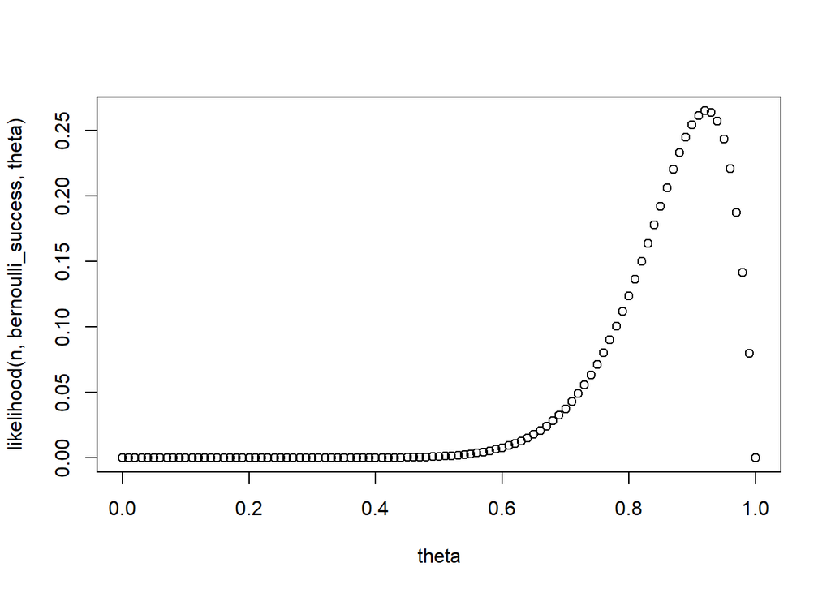

```r
test <- c(1,0,1,0,1,1,1,1,0,1,0,0,1,0,0,1,0,1,1,1,0)
X1 <- seq(0, 1, by=0.01)

n = 21
bernoulli_success = 12
theta <- X1

likelihood = function(n, bernoulli_success, theta){
  return(theta^bernoulli_success*(1-theta)*(n - bernoulli_success)) }

plot(theta, likelihood(n,bernoulli_success, theta))
```

7. At which step did the 95% credible interval go completely above 0.5?